# Ford GoBike Data

### by Kyrillos Zakher

# Introduction

This data set includes information about individual rides made in a bike-sharing system covering the greater San Francisco Bay area.

So let's have a deep look on this dataset to get some useful findings about it.

## The average duration of the bike rides.

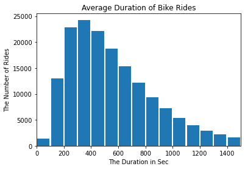

#### As we see above, the most average duration of the bike rides is from 200 to 600 Secs, This means that most of people use bikes for quick rides.

## The number of rides based on the gender

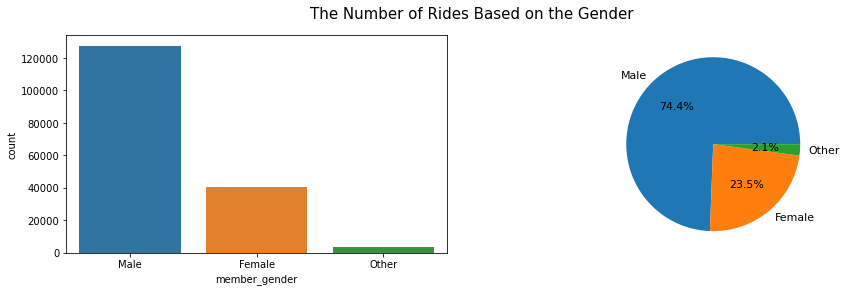

#### The number of males is much more than the other genders.

## The number of rides based on the ages.

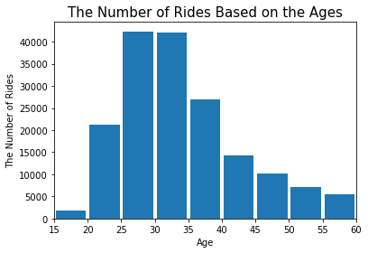

#### As we see, the ages from 25 to 35 years tends to make more rides than others.

## The day of a week which people tend to make more rides.

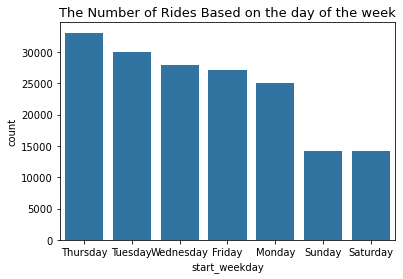

#### Thursday and Tuesday are the most days on which people make more rides. On the other hand, saturday and sunday are the most days on which people make few rides. I think the reason is these days are weekends and people prefer to stay at home or travell together.

## The hour of the day at which people tend to make more rides.

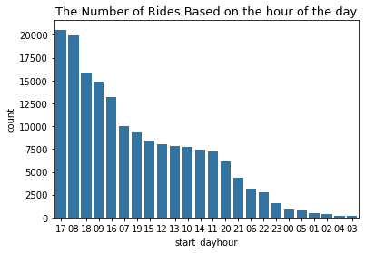

#### The most rides happened at (5-6) PM at the sunset and (8-9) AM in the morning.

## The day of a week on which each gender prefers to go in a trip ?

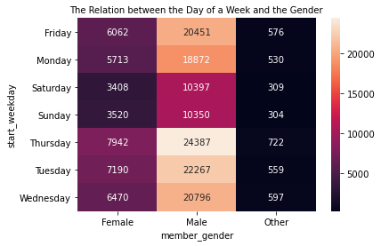

#### All Genders prefer thursdays for the trip.

## The hour of a day at which each gender prefers to go in a trip ?

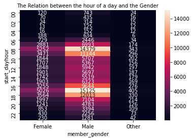

## The relation between the ages, genders and the duration of the trip.

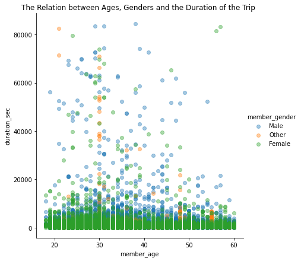

## The number of trips by hour of the day based on the user type.

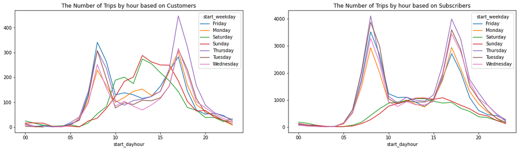

For Customers, the number of trips increased on Thursday at 5-6 PM.

On the other hand for subscribers, the number of trips increased on thursday and tuesday at 8-9 AM, and on thursday at 5-6 PM.

## The number of trips by hour of the day based on gender.

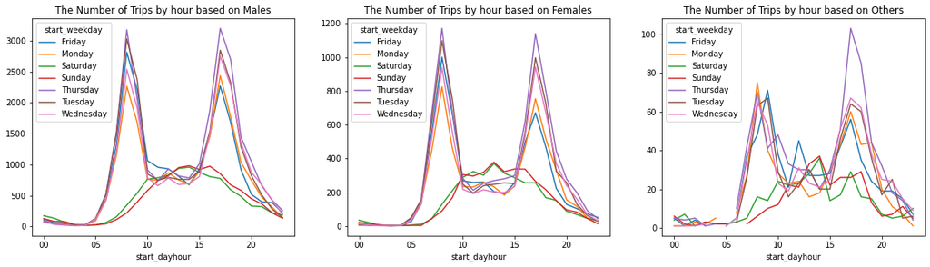

For Males, the number of trips increased on Thursday at 8AM and 5 PM.

For females, the number of trips increased on Thursday and Tuesday at 8AM and on Thursday at 5 PM.

For Others, the number of trips highly increased on Thursday at 5 PM.

# Conclusion

After invetsigation in FordGoBike service on Feb 2019, It's found that :

- Age

  The ages from 25 to 35 years tends to make more rides than others.

  The most long trip durations take place by 30-year old persons.
- Gender

  The number of males is much more than the other genders.

  All Genders prefer thursdays for the trip.

  The most average duration of the bike rides is from 200 to 600 Secs, This means that most of people use bikes for quick rides.
- Days of a week

  Thursday and Tuesday are the most days on which people make more rides. On the other hand, saturday and sunday are the most days on which people make few rides. I think the reason is these days are weekends and people prefer to stay at home or travell together.

  The most rides happened at (5-6) PM at the sunset and (8-9) AM in the morning.
- Distance

  For Customers, the number of trips increased on Thursday at 5-6 PM.

  On the other hand for subscribers, the number of trips increased on thursday and tuesday at 8-9 AM, and on thursday at 5-6 PM.

# Thank You :)